# Funding in US Politics

Fall 2024 Data Science Project

Rithvik Kommareddy

## Introduction

There is currently increasing contention in the political landscape. Because of this, it is increasingly important to understand the factors that impact a candidates chance of success. In particular, this project will focus on the effect of funding on a candidates chances.

The purpose of this project is to examine relations between party, funding, and chances of election. Key questions will include: How much money is necessary to win an election? How does party affect funding? Can these factors accurately predict a candidate's chances of victory?

## Data Curation

The Federal Election Committee collects data on the campaign contributions of every registered canditate for presidency, the Senate, and the House of Representatives. This data also includes the candidate's states, party affiliation, and whether they are incumbant, a challenger, or if the seat is open.

Data is sourced from https://www.fec.gov/data/browse-data/?tab=candidates

```python
import numpy as np
import pandas as pd
import matplotlib.pyplot as plt
from sklearn.model_selection import train_test_split, cross_val_score, StratifiedKFold
from sklearn.ensemble import RandomForestRegressor
from sklearn.linear_model import LinearRegression

#import data
df2008 = pd.read_csv('candidate_summary_2008.csv')
df2010 = pd.read_csv('candidate_summary_2010.csv')
df2012 = pd.read_csv('candidate_summary_2012.csv')
df2014 = pd.read_csv('candidate_summary_2014.csv')
df2016 = pd.read_csv('candidate_summary_2016.csv')
df2018 = pd.read_csv('candidate_summary_2018.csv')
df2020 = pd.read_csv('candidate_summary_2020.csv')
df2022 = pd.read_csv('candidate_summary_2022.csv')
df2024 = pd.read_csv('candidate_summary_2024.csv')

dfs = [df2008,df2010,df2012,df2014,df2016,df2018,df2020,df2022,df2024]
```

## Exploratory Data Analysis

```python
print(df2008.shape)
print(df2010.shape)
print(df2012.shape)
print(df2014.shape)
print(df2016.shape)
print(df2018.shape)
print(df2020.shape)
print(df2022.shape)
print(df2024.shape)
```

```
(2737, 50)
(3469, 50)
(3483, 50)
(2692, 50)
(4638, 50)
(3792, 50)
(5131, 50)
(4534, 50)
(5284, 50)
```

Each dataframe has between 2692 and 5284 candidates. They all have 50 features. The most important categories are total contribution, other contribution (which is mostly from PACs), and party affiliation.

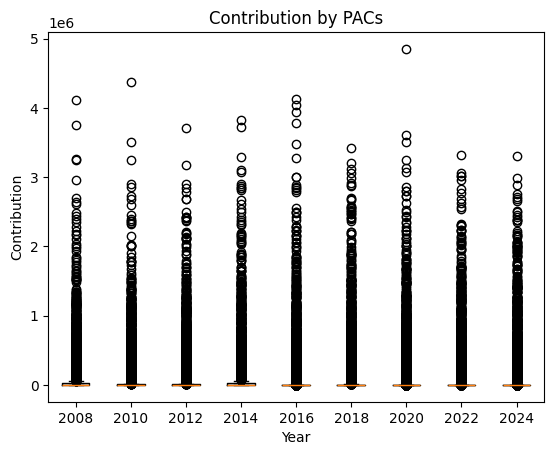

```python
pac2008 = df2008['Other_Committee_Contribution']
pac2010 = df2010['Other_Committee_Contribution']
pac2012 = df2012['Other_Committee_Contribution']
pac2014 = df2014['Other_Committee_Contribution']
pac2016 = df2016['Other_Committee_Contribution']
pac2018 = df2018['Other_Committee_Contribution']
pac2020 = df2020['Other_Committee_Contribution']
pac2022 = df2022['Other_Committee_Contribution']
pac2024 = df2024['Other_Committee_Contribution']

fig, ax = plt.subplots()
ax.set_xlabel('Year')
ax.set_ylabel('Contribution')
ax.set_title('Contribution by PACs')
ax.boxplot([pac2008,pac2010,pac2012,pac2014,pac2016,pac2018,pac2020,pac2022,pac2024],labels=['2008','2010','2012','2014','2016','2018','2020','2022','2024'])
plt.show()
```

It seems that the mean and every quartile are approximately zero, and there is an extreme number and range of outliers. Next I will try making boxplots while ignoring all candidates with zero dollars contributed.

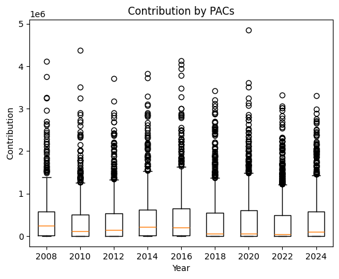

```python
pac2008 = df2008['Other_Committee_Contribution'][df2008.Other_Committee_Contribution != 0]
pac2010 = df2010['Other_Committee_Contribution'][df2010.Other_Committee_Contribution != 0]
pac2012 = df2012['Other_Committee_Contribution'][df2012.Other_Committee_Contribution != 0]
pac2014 = df2014['Other_Committee_Contribution'][df2014.Other_Committee_Contribution != 0]
pac2016 = df2016['Other_Committee_Contribution'][df2016.Other_Committee_Contribution != 0]
pac2018 = df2018['Other_Committee_Contribution'][df2018.Other_Committee_Contribution != 0]
pac2020 = df2020['Other_Committee_Contribution'][df2020.Other_Committee_Contribution != 0]
pac2022 = df2022['Other_Committee_Contribution'][df2022.Other_Committee_Contribution != 0]
pac2024 = df2024['Other_Committee_Contribution'][df2024.Other_Committee_Contribution != 0]

fig, ax = plt.subplots()
ax.set_xlabel('Year')
ax.set_ylabel('Contribution')
ax.set_title('Contribution by PACs')
ax.boxplot([pac2008,pac2010,pac2012,pac2014,pac2016,pac2018,pac2020,pac2022,pac2024],labels=['2008','2010','2012','2014','2016','2018','2020','2022','2024'])
plt.show()
```

There is now noticeable difference between the quartiles, but there are still many high outliers but no lower outliers. In addition, the distributions are all right skewed. This implies that a disproportionate amount of contributions go to the top recieving candidates.

Next I will organize PAC donations by party in select years.

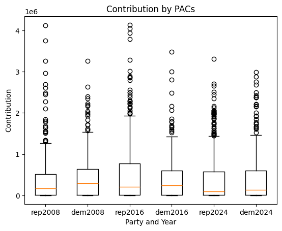

```python
rep2008 = df2008['Other_Committee_Contribution'][(df2008.Other_Committee_Contribution != 0) & (df2008.Cand_Party_Affiliation == 'REP')]
dem2008 = df2008['Other_Committee_Contribution'][(df2008.Other_Committee_Contribution != 0) & (df2008.Cand_Party_Affiliation == 'DEM')]
rep2016 = df2016['Other_Committee_Contribution'][(df2016.Other_Committee_Contribution != 0) & (df2016.Cand_Party_Affiliation == 'REP')]
dem2016 = df2016['Other_Committee_Contribution'][(df2016.Other_Committee_Contribution != 0) & (df2016.Cand_Party_Affiliation == 'DEM')]
rep2024 = df2024['Other_Committee_Contribution'][(df2024.Other_Committee_Contribution != 0) & (df2024.Cand_Party_Affiliation == 'REP')]
dem2024 = df2024['Other_Committee_Contribution'][(df2024.Other_Committee_Contribution != 0) & (df2024.Cand_Party_Affiliation == 'DEM')]

fig, ax = plt.subplots()
ax.set_xlabel('Party and Year')
ax.set_ylabel('Contribution')
ax.set_title('Contribution by PACs')
ax.boxplot([rep2008,dem2008,rep2016,dem2016,rep2024,dem2024], labels = ['rep2008','dem2008','rep2016','dem2016','rep2024','dem2024'])
plt.show()
```

I will also investigate the difference in total PAC contribution between parties.

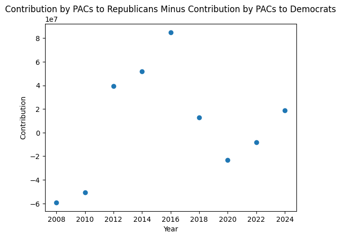

```python
pac2008 = df2008['Other_Committee_Contribution'][df2008.Cand_Party_Affiliation == 'REP'].sum() - df2008['Other_Committee_Contribution'][df2008.Cand_Party_Affiliation == 'DEM'].sum()
pac2010 = df2010['Other_Committee_Contribution'][df2010.Cand_Party_Affiliation == 'REP'].sum() - df2010['Other_Committee_Contribution'][df2010.Cand_Party_Affiliation == 'DEM'].sum()
pac2012 = df2012['Other_Committee_Contribution'][df2012.Cand_Party_Affiliation == 'REP'].sum() - df2012['Other_Committee_Contribution'][df2012.Cand_Party_Affiliation == 'DEM'].sum()
pac2014 = df2014['Other_Committee_Contribution'][df2014.Cand_Party_Affiliation == 'REP'].sum() - df2014['Other_Committee_Contribution'][df2014.Cand_Party_Affiliation == 'DEM'].sum()
pac2016 = df2016['Other_Committee_Contribution'][df2016.Cand_Party_Affiliation == 'REP'].sum() - df2016['Other_Committee_Contribution'][df2016.Cand_Party_Affiliation == 'DEM'].sum()
pac2018 = df2018['Other_Committee_Contribution'][df2018.Cand_Party_Affiliation == 'REP'].sum() - df2018['Other_Committee_Contribution'][df2018.Cand_Party_Affiliation == 'DEM'].sum()
pac2020 = df2020['Other_Committee_Contribution'][df2020.Cand_Party_Affiliation == 'REP'].sum() - df2020['Other_Committee_Contribution'][df2020.Cand_Party_Affiliation == 'DEM'].sum()
pac2022 = df2022['Other_Committee_Contribution'][df2022.Cand_Party_Affiliation == 'REP'].sum() - df2022['Other_Committee_Contribution'][df2022.Cand_Party_Affiliation == 'DEM'].sum()
pac2024 = df2024['Other_Committee_Contribution'][df2024.Cand_Party_Affiliation == 'REP'].sum() - df2024['Other_Committee_Contribution'][df2024.Cand_Party_Affiliation == 'DEM'].sum()

fig, ax = plt.subplots()
ax.set_xlabel('Year')
ax.set_ylabel('Contribution')
ax.set_title('Contribution by PACs to Republicans Minus Contribution by PACs to Democrats')
ax.scatter(range(2008,2026,2),[pac2008,pac2010,pac2012,pac2014,pac2016,pac2018,pac2020,pac2022,pac2024])
plt.show()
```

This is the same thing, but with averages.

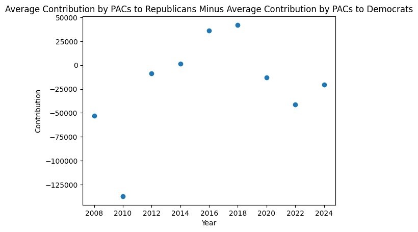

```python
pac2008 = df2008['Other_Committee_Contribution'][df2008.Cand_Party_Affiliation == 'REP'].mean() - df2008['Other_Committee_Contribution'][df2008.Cand_Party_Affiliation == 'DEM'].mean()
pac2010 = df2010['Other_Committee_Contribution'][df2010.Cand_Party_Affiliation == 'REP'].mean() - df2010['Other_Committee_Contribution'][df2010.Cand_Party_Affiliation == 'DEM'].mean()
pac2012 = df2012['Other_Committee_Contribution'][df2012.Cand_Party_Affiliation == 'REP'].mean() - df2012['Other_Committee_Contribution'][df2012.Cand_Party_Affiliation == 'DEM'].mean()
pac2014 = df2014['Other_Committee_Contribution'][df2014.Cand_Party_Affiliation == 'REP'].mean() - df2014['Other_Committee_Contribution'][df2014.Cand_Party_Affiliation == 'DEM'].mean()
pac2016 = df2016['Other_Committee_Contribution'][df2016.Cand_Party_Affiliation == 'REP'].mean() - df2016['Other_Committee_Contribution'][df2016.Cand_Party_Affiliation == 'DEM'].mean()
pac2018 = df2018['Other_Committee_Contribution'][df2018.Cand_Party_Affiliation == 'REP'].mean() - df2018['Other_Committee_Contribution'][df2018.Cand_Party_Affiliation == 'DEM'].mean()
pac2020 = df2020['Other_Committee_Contribution'][df2020.Cand_Party_Affiliation == 'REP'].mean() - df2020['Other_Committee_Contribution'][df2020.Cand_Party_Affiliation == 'DEM'].mean()
pac2022 = df2022['Other_Committee_Contribution'][df2022.Cand_Party_Affiliation == 'REP'].mean() - df2022['Other_Committee_Contribution'][df2022.Cand_Party_Affiliation == 'DEM'].mean()
pac2024 = df2024['Other_Committee_Contribution'][df2024.Cand_Party_Affiliation == 'REP'].mean() - df2024['Other_Committee_Contribution'][df2024.Cand_Party_Affiliation == 'DEM'].mean()

fig, ax = plt.subplots()
ax.set_xlabel('Year')
ax.set_ylabel('Contribution')
ax.set_title('Average Contribution by PACs to Republicans Minus Average Contribution by PACs to Democrats')
ax.scatter(range(2008,2026,2),[pac2008,pac2010,pac2012,pac2014,pac2016,pac2018,pac2020,pac2022,pac2024])
plt.show()
```

And again, ignoring candidates who recieved no contributions from PACs.

```
8695.282814124308
```

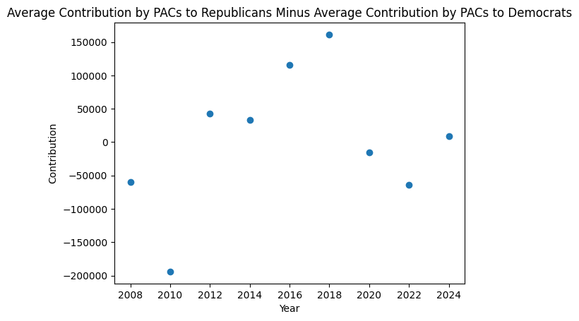

```python
pac2008 = df2008['Other_Committee_Contribution'][(df2008.Other_Committee_Contribution != 0) & (df2008.Cand_Party_Affiliation == 'REP')].mean() - df2008['Other_Committee_Contribution'][(df2008.Other_Committee_Contribution != 0) & (df2008.Cand_Party_Affiliation == 'DEM')].mean()
pac2010 = df2010['Other_Committee_Contribution'][(df2010.Other_Committee_Contribution != 0) & (df2010.Cand_Party_Affiliation == 'REP')].mean() - df2010['Other_Committee_Contribution'][(df2010.Other_Committee_Contribution != 0) & (df2010.Cand_Party_Affiliation == 'DEM')].mean()
pac2012 = df2012['Other_Committee_Contribution'][(df2012.Other_Committee_Contribution != 0) & (df2012.Cand_Party_Affiliation == 'REP')].mean() - df2012['Other_Committee_Contribution'][(df2012.Other_Committee_Contribution != 0) & (df2012.Cand_Party_Affiliation == 'DEM')].mean()
pac2014 = df2014['Other_Committee_Contribution'][(df2014.Other_Committee_Contribution != 0) & (df2014.Cand_Party_Affiliation == 'REP')].mean() - df2014['Other_Committee_Contribution'][(df2014.Other_Committee_Contribution != 0) & (df2014.Cand_Party_Affiliation == 'DEM')].mean()
pac2016 = df2016['Other_Committee_Contribution'][(df2016.Other_Committee_Contribution != 0) & (df2016.Cand_Party_Affiliation == 'REP')].mean() - df2016['Other_Committee_Contribution'][(df2016.Other_Committee_Contribution != 0) & (df2016.Cand_Party_Affiliation == 'DEM')].mean()
pac2018 = df2018['Other_Committee_Contribution'][(df2018.Other_Committee_Contribution != 0) & (df2018.Cand_Party_Affiliation == 'REP')].mean() - df2018['Other_Committee_Contribution'][(df2018.Other_Committee_Contribution != 0) & (df2018.Cand_Party_Affiliation == 'DEM')].mean()
pac2020 = df2020['Other_Committee_Contribution'][(df2020.Other_Committee_Contribution != 0) & (df2020.Cand_Party_Affiliation == 'REP')].mean() - df2020['Other_Committee_Contribution'][(df2020.Other_Committee_Contribution != 0) & (df2020.Cand_Party_Affiliation == 'DEM')].mean()
pac2022 = df2022['Other_Committee_Contribution'][(df2022.Other_Committee_Contribution != 0) & (df2022.Cand_Party_Affiliation == 'REP')].mean() - df2022['Other_Committee_Contribution'][(df2022.Other_Committee_Contribution != 0) & (df2022.Cand_Party_Affiliation == 'DEM')].mean()
pac2024 = df2024['Other_Committee_Contribution'][(df2024.Other_Committee_Contribution != 0) & (df2024.Cand_Party_Affiliation == 'REP')].mean() - df2024['Other_Committee_Contribution'][(df2024.Other_Committee_Contribution != 0) & (df2024.Cand_Party_Affiliation == 'DEM')].mean()

fig, ax = plt.subplots()
ax.set_xlabel('Year')
ax.set_ylabel('Contribution')
ax.set_title('Average Contribution by PACs to Republicans Minus Average Contribution by PACs to Democrats')
ax.scatter(range(2008,2026,2),[pac2008,pac2010,pac2012,pac2014,pac2016,pac2018,pac2020,pac2022,pac2024])
print(pac2024)
plt.show()
```

When these adjustments are made, the value for every year is in the negatives except for 2012 through 2018, as well as 2024. This means that, ignoring candidates who recieved no contributions from PACs, democratic candidates have recieved, on average, more contributions from PACS in 2008, 2010, 2020, and 2022.

Next, I will try to find if the amount spent on elections is increasing over time.

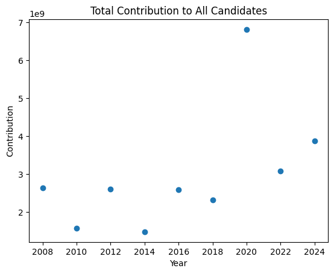

```python
pac2008 = df2008['Total_Contribution'].sum()
pac2010 = df2010['Total_Contribution'].sum()
pac2012 = df2012['Total_Contribution'].sum()
pac2014 = df2014['Total_Contribution'].sum()
pac2016 = df2016['Total_Contribution'].sum()
pac2018 = df2018['Total_Contribution'].sum()
pac2020 = df2020['Total_Contribution'].sum()
pac2022 = df2022['Total_Contribution'].sum()
pac2024 = df2024['Total_Contribution'].sum()

fig, ax = plt.subplots()
ax.set_xlabel('Year')
ax.set_ylabel('Contribution')
ax.set_title('Total Contribution to All Candidates')
ax.scatter(range(2008,2026,2),[pac2008,pac2010,pac2012,pac2014,pac2016,pac2018,pac2020,pac2022,pac2024])
plt.show()
```

It seems that presidential election years have greater total contributions, and the amount of contributions on presidential election years and non presidential election years remained approximately constant up to 2016. After 2016, the contributions appear to be higher than in previous years, with 2020 being notable for having an extremely high amount of contributions. However, with only nine data points, one of which might be an outlier, this question is not suitable for hypothesis testing.

## Primary Analysis

Since we have seen that there seems to be differences between funding recieved by Democrats and Republicans, but this does not correspond neatly to a linear model dependent solely on time, I will try to add some dimensions to predict the funding a candidate will recieve. Furthermore, I will try to create a model that functions well regardless of time, so it can be used to predict how much funding a candidate will recieve in the next election. Because the total amount spent varies by year, I will instead try to find the percentage of total funding that a candidate will get. Since this is a task with a low dimensionality and discrete variables, a decision tree will be a good choice. In addition, using a random forest will increase the accuracy of the analysis.

```python
# First a column needs to be added for the percentage of funding recieved. Not counting presidential candidates because they dominate the funding percentages
for df in dfs:
  total = df['Total_Contribution'][df.Cand_Office != 'P'].sum()
  df['Percent_Contribution'] = 100 * df['Total_Contribution'] / total

# Combining dataframes
data = pd.concat(dfs)

# Removing presidential candidates
data = data[data.Cand_Office != 'P']

# Because there are many rows, NA can be dropped
data.dropna(inplace=True)

# Removing candidates that recieveded too little contribution to narrow down to candidates running serious campaigns.
data = data[data.Percent_Contribution > .01]

data
```

|  | Link_Image | Cand_Name | Cand_Id | Cand_Office | Cand_Office_St | Cand_Office_Dist | Cand_Party_Affiliation | Cand_Incumbent_Challenger_Open_Seat | Total_Receipt | Total_Disbursement | ... | Party_Committee_Refund | Other_Committee_Refund | Total_Contribution_Refund | Other_Disbursements | Net_Contribution | Net_Operating_Expenditure | Cash_On_Hand_BOP | Debt_Owe_To_Committee | Coverage_Start_Date | Percent_Contribution |
| --- | --- | --- | --- | --- | --- | --- | --- | --- | --- | --- | --- | --- | --- | --- | --- | --- | --- | --- | --- | --- | --- |
| 3 | https://www.fec.gov/data/candidate/H8FL06080/?... | CUNHA, TIMOTHY M | H8FL06080 | H | FL | 6.0 | DEM | CHALLENGER | 249756.94 | 249756.94 | ... | 0.0 | 0.0 | 25.00 | 0.00 | 128731.94 | 149716.00 | 0.00 | 0.0 | 04/01/2008 | 0.010444 |
| 22 | https://www.fec.gov/data/candidate/H0OH08029/?... | BOEHNER, JOHN A | H0OH08029 | H | OH | 8.0 | REP | INCUMBENT | 5161991.51 | 5345278.99 | ... | 0.0 | 1700.0 | 18650.00 | 2574824.33 | 3917799.20 | 1587451.14 | 389592.82 | 0.0 | 01/01/2007 | 0.319310 |
| 24 | https://www.fec.gov/data/candidate/H0PA04154/?... | HART, MELISSA A | H0PA04154 | H | PA | 4.0 | REP | CHALLENGER | 1362709.71 | 1362532.36 | ... | 0.0 | 400.0 | 6200.00 | 1122.49 | 1345917.11 | 1349306.83 | 8198.23 | 0.0 | 01/01/2007 | 0.109679 |
| 32 | https://www.fec.gov/data/candidate/H8IL16062/?... | ABBOUD, ROBERT | H8IL16062 | H | IL | 16.0 | DEM | CHALLENGER | 516013.69 | 501321.24 | ... | 0.0 | 0.0 | 0.00 | 0.00 | 429317.64 | 501321.24 | 0.00 | 80.0 | 06/01/2007 | 0.034825 |
| 172 | https://www.fec.gov/data/candidate/H8LA00017/?... | CASSIDY, WILLIAM | H8LA00017 | H | LA | 6.0 | REP | CHALLENGER | 1295445.83 | 1252461.37 | ... | 0.0 | 0.0 | 15500.00 | 2000.00 | 1223200.90 | 1163247.94 | 0.00 | 0.0 | 04/01/2008 | 0.100479 |
| ... | ... | ... | ... | ... | ... | ... | ... | ... | ... | ... | ... | ... | ... | ... | ... | ... | ... | ... | ... | ... | ... |
| 5143 | https://www.fec.gov/data/candidate/S4OH00200/?... | LAROSE, FRANK | S4OH00200 | S | OH | 0.0 | REP | CHALLENGER | 2338465.29 | 2319907.19 | ... | 0.0 | 6000.0 | 144984.12 | 7245.00 | 1937181.17 | 1936378.07 | 0.00 | 0.0 | 07/01/2023 | 0.079722 |
| 5148 | https://www.fec.gov/data/candidate/H2MI10176/?... | MARLINGA, CARL J. | H2MI10176 | H | MI | 10.0 | DEM | CHALLENGER | 2596072.02 | 1710908.41 | ... | 0.0 | 0.0 | 18066.85 | 1400.00 | 2285512.23 | 1691441.56 | 5906.37 | 0.0 | 01/01/2023 | 0.088199 |
| 5155 | https://www.fec.gov/data/candidate/H4CO03357/?... | HURD, JEFFREY | H4CO03357 | H | CO | 3.0 | REP | OPEN | 2410147.01 | 2097864.56 | ... | 0.0 | 7000.0 | 13850.00 | 0.00 | 2393059.59 | 2082959.70 | 0.00 | 0.0 | 07/01/2023 | 0.092156 |
| 5243 | https://www.fec.gov/data/candidate/H2FL11117/?... | SABATINI, ANTHONY | H2FL11117 | H | FL | 11.0 | REP | CHALLENGER | 378035.27 | 385204.10 | ... | 0.0 | 0.0 | 22800.00 | 0.00 | 322780.27 | 331778.44 | 536.00 | 0.0 | 01/01/2023 | 0.013232 |
| 5272 | https://www.fec.gov/data/candidate/S4TX00755/?... | GUTIERREZ, ROLAND | S4TX00755 | S | TX | 0.0 | DEM | CHALLENGER | 1446695.19 | 1446897.57 | ... | 0.0 | 1000.0 | 69963.88 | 0.00 | 1373711.15 | 1376913.53 | 0.00 | 0.0 | 07/09/2023 | 0.055275 |

729 rows × 51 columns

```python
# Extracting useful columns. Because these are all discrete, the data does not need to be normalized
X = data[['Cand_Office','Cand_Office_St','Cand_Office_Dist','Cand_Party_Affiliation','Cand_Incumbent_Challenger_Open_Seat']]
Y = data[['Percent_Contribution']]

# Rewriting text as numbers
X[['Cand_Office','Cand_Office_St','Cand_Party_Affiliation','Cand_Incumbent_Challenger_Open_Seat']] = X[['Cand_Office','Cand_Office_St','Cand_Party_Affiliation','Cand_Incumbent_Challenger_Open_Seat']].apply(lambda x: pd.factorize(x)[0])
X
```

|  | Cand_Office | Cand_Office_St | Cand_Office_Dist | Cand_Party_Affiliation | Cand_Incumbent_Challenger_Open_Seat |
| --- | --- | --- | --- | --- | --- |
| 3 | 0 | 0 | 6.0 | 0 | 0 |
| 22 | 0 | 1 | 8.0 | 1 | 1 |
| 24 | 0 | 2 | 4.0 | 1 | 0 |
| 32 | 0 | 3 | 16.0 | 0 | 0 |
| 172 | 0 | 4 | 6.0 | 1 | 0 |
| ... | ... | ... | ... | ... | ... |
| 5143 | 1 | 1 | 0.0 | 1 | 0 |
| 5148 | 0 | 11 | 10.0 | 0 | 0 |
| 5155 | 0 | 8 | 3.0 | 1 | 2 |
| 5243 | 0 | 0 | 11.0 | 1 | 0 |
| 5272 | 1 | 21 | 0.0 | 0 | 0 |

729 rows × 5 columns

```python
seed = 7930285

X_train,X_test,Y_train,Y_test = train_test_split(X, Y, test_size = .2, random_state=seed)

model = RandomForestRegressor(n_estimators=10,max_depth=10,random_state=seed)
model.fit(X_train,Y_train)

model.score(X_test,Y_test)
```

```
0.622831952480922
```

This model accounts for more than sixty percent of the variance in the test data. This is much higher than I expected, considering all the factors in a political campaign that can not be accounted for statistically.

## Visualization

A table of the importance of each feature can help us to determine which factors are most important to consider when assessing hwo much funding a campaign will recieve.

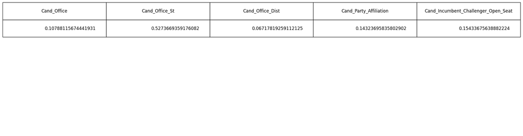

```python
fig, ax = plt.subplots()

fig.patch.set_visible(False)
ax.axis('tight')
ax.axis('off')

table = ax.table(cellText=[model.feature_importances_], colLabels=X.columns,loc='top')

table.auto_set_font_size(False)
table.set_fontsize(12)
table.scale(4, 4)

fig.tight_layout()
plt.show()
```

## Insights and Conclusions

From the table, it can be seen that the state in which a candidate runs in the most significant factor in how much funding they will recieve by a large margin. The district that a candidate runs in is, on the contrary, the least important feature. This implies that the district feature might just be noise, and further analysis should not be more specific than the state level. Candidate office is similarly lowly weighted, implying Senators and Representatives recieve similar contributions. Party and Incumbant status have slightly higher impacts, meaning these measures should be kept. Because this model did not account for a lot of the variance, future analysis should consider using a different model and features not used here, such as google searches for a candidates names or positions on key issues.